# bike rental

```python
# Importing libraries for data analysis and visualization
import pandas as pd
import matplotlib.pyplot as plt
import seaborn as sns

# This makes sure your graphs appear inside the notebook
%matplotlib inline
```

```
Matplotlib is building the font cache; this may take a moment.
```

```python
# Load the Excel file named "bikes_data.xlsx"
df = pd.read_excel('bikes_data.xlsx')

# Show the first 5 rows of the data
df.head()
```

|  | ID | Month | Day of Week | Hour | Temperature | Humidity | Wind Speed | Visibility | Dew Point Temperature | UV Index | Rainfall | Snowfall | Season | Holiday | RENTALS |
| --- | --- | --- | --- | --- | --- | --- | --- | --- | --- | --- | --- | --- | --- | --- | --- |
| 0 | 1 | Jan | Sunday | 0 | -3.2 | 40 | 0.5 | 1358 | -14.9 | 0.00 | 0.0 | 0.0 | Winter | Yes | 221 |
| 1 | 2 | Jan | Sunday | 13 | 2.4 | 22 | 2.3 | 1921 | -17.2 | 1.10 | 0.0 | 0.0 | Winter | Yes | 268 |
| 2 | 3 | Jan | Sunday | 16 | 3.0 | 28 | 2.5 | 1864 | -13.7 | 0.51 | 0.0 | 0.0 | Winter | Yes | 335 |
| 3 | 4 | Jan | Sunday | 17 | 1.8 | 33 | 3.3 | 1913 | -12.8 | 0.18 | 0.0 | 0.0 | Winter | Yes | 299 |
| 4 | 5 | Jan | Sunday | 20 | -0.3 | 40 | 1.2 | 1936 | -12.2 | 0.00 | 0.0 | 0.0 | Winter | Yes | 225 |

```python
# Shows total number of rows and columns in the dataset
df.shape

# Lists all column names
df.columns

# Shows 10 random rows from the dataset
df.sample(10)
```

|  | ID | Month | Day of Week | Hour | Temperature | Humidity | Wind Speed | Visibility | Dew Point Temperature | UV Index | Rainfall | Snowfall | Season | Holiday | RENTALS |
| --- | --- | --- | --- | --- | --- | --- | --- | --- | --- | --- | --- | --- | --- | --- | --- |
| 1214 | 1215 | Nov | Monday | 7 | 4.4 | 72 | 0.3 | 1189 | -0.2 | 0.00 | 0.0 | 0.0 | Autumn | No | 1141 |
| 641 | 642 | June | Thursday | 19 | 24.3 | 48 | 1.5 | 2000 | 12.5 | 0.59 | 0.0 | 0.0 | Summer | No | 3223 |
| 47 | 48 | Jan | Saturday | 12 | 1.2 | 58 | 0.8 | 550 | -6.1 | 0.74 | 0.0 | 0.0 | Winter | No | 240 |
| 1057 | 1058 | Oct | Tuesday | 6 | 11.4 | 84 | 0.3 | 1742 | 8.7 | 0.00 | 0.0 | 0.0 | Autumn | Yes | 292 |
| 1372 | 1373 | Dec | Friday | 9 | 1.2 | 67 | 0.2 | 591 | -4.2 | 0.06 | 0.0 | 0.0 | Winter | No | 389 |
| 324 | 325 | Mar | Sunday | 14 | 17.4 | 39 | 2.9 | 520 | 3.2 | 2.70 | 0.0 | 0.0 | Spring | No | 633 |
| 741 | 742 | July | Monday | 6 | 20.7 | 97 | 0.9 | 2000 | 20.2 | 0.02 | 0.0 | 0.0 | Summer | No | 561 |
| 314 | 315 | Mar | Thursday | 9 | 3.3 | 72 | 1.4 | 618 | -1.2 | 0.61 | 0.0 | 0.0 | Spring | No | 704 |
| 625 | 626 | June | Monday | 13 | 25.7 | 46 | 0.8 | 2000 | 13.2 | 3.18 | 0.0 | 0.0 | Summer | No | 1301 |
| 1356 | 1357 | Dec | Sunday | 1 | 5.6 | 78 | 0.5 | 197 | 2.0 | 0.00 | 0.0 | 0.0 | Winter | Yes | 274 |

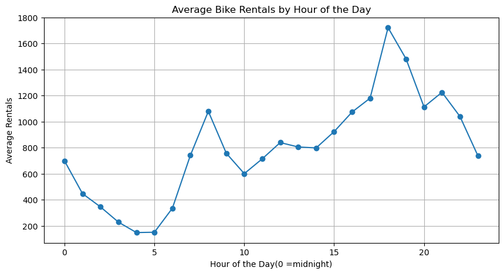

```python
# Grouping the data by hour and calculating the average rentals for each hour
avg_hourly = df.groupby('Hour')['RENTALS'].mean()

# plotting a line chart to show rental trends by hour
plt.figure(figsize=(10,5))
plt.plot(avg_hourly.index, avg_hourly.values, marker='o')
plt.title('Average Bike Rentals by Hour of the Day')
plt.xlabel('Hour of the Day(0 =midnight)')
plt.ylabel('Average Rentals')
plt.grid(True)
plt.show()
```

This graph clearly shows that most people rent bikes in the morning and evening time. I think this is because they are going to work or coming back. Very few people rent bikes during the night. The company should make sure bikes are available during busy hours like 8 AM and 6 PM. This can improve service and make more customers happy.

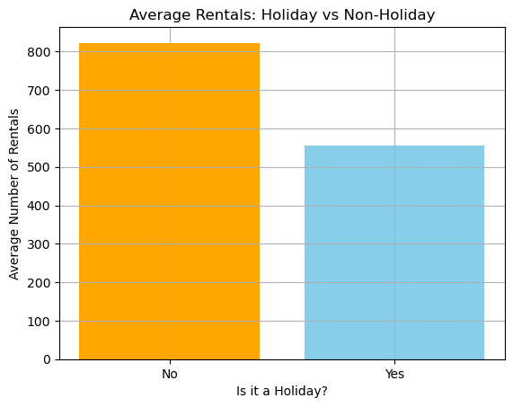

```python
# Grouping the data by Holiday and calculating average rentals
holiday_avg = df.groupby('Holiday')['RENTALS'].mean().reset_index()

# Creating a bar chart from the new DataFrame
plt.bar(holiday_avg['Holiday'], holiday_avg['RENTALS'], color=['orange','skyblue'])
plt.title("Average Rentals: Holiday vs Non-Holiday")
plt.xlabel("Is it a Holiday?")
plt.ylabel("Average Number of Rentals")
plt.grid(True)
plt.show()
```

This chart clearly shows that bike rentals are more on regular days compared to holidays. I think it’s because on holidays, people usually relax, stay home, or go out by car with family. But on working days, people use bikes for their daily routine like office or school. That’s why the average rentals are higher on normal weekdays. Bay Wheels should focus more on weekdays and not waste resources on holidays.

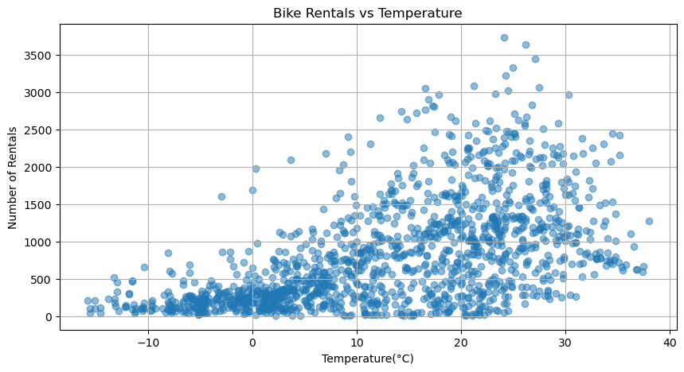

```python
# This plot shows how bike rentals change with temperature
plt.figure(figsize=(10,5))
plt.scatter(df['Temperature'], df['RENTALS'], alpha=0.5)
plt.title("Bike Rentals vs Temperature")
plt.xlabel("Temperature(°C)")
plt.ylabel("Number of Rentals")
plt.grid(True)
plt.show()
```

This chart shows that rentals are low when the temperature is very cold. But as the weather gets warmer, people start renting more bikes. The best rental activity happens when the temperature is between 15 and 25 degrees. So temperature clearly affects user behavior. The company should prepare more bikes during these ideal weather days.

My top three insight

First thing I saw is that most people rent bikes early morning and evening time. The peak is around 8 AM and again around 6 PM. I think it’s because people are going to office or coming back home from work or college. Hardly anyone rents bikes at night, which is expected. So Bay Wheels should put more bikes during rush hours to make sure people get bikes when they actually need it.

Second, I noticed that rentals are more on normal weekdays than holidays. On holidays, people relax, stay at home or maybe use car for outing with family. But on regular working days, bikes are used more for daily travel like going to office or classes. That’s why the rentals are higher on non-holidays. So Bay Wheels should focus on weekdays more and not waste bikes on holidays when demand is low.

Third, temperature really makes a difference. When it’s too cold like below 5 degrees, not many people rent bikes. But when it’s between 15 to 25 degrees, that’s when rentals go very high. People prefer riding bikes in comfortable weather. So Bay Wheels should watch the weather and send more bikes outside on warmer sunny days.

Conclusion

This project helped me understand how data can tell us real-life patterns. From this dataset, I saw how people use bikes more during weekdays, morning-evening times, and when the weather is nice. All of this makes sense when I think about daily routines. If a company like Bay Wheels uses this data properly, they can improve customer service and grow their business. I learned how to use Python and graphs to find these patterns, and I really enjoyed seeing real results from data.

Source

World Bank. (2023). *Digital access and infrastructure overview*. https://www.worldbank.org/

Bay Wheels. (2022). *Annual System Data Report*. https://www.lyft.com/bikes/bay-wheels/system-data